# bikeshare (2nd try)

## Problems to solve

– I will use the correct statistical distribution (Poisson), if possible. GBM is able to choose the distribution function.

– I will use count instead of lgcount, and implement the rmsle as metric again.

– feature of holiday is redaudant (covered by wday + workingday), so take it out. season is perhaps useless, too.

– I should do more careful feature selections

– I will try to use more regression pacific algorithm + SVM + …

## Data

```r
train <- read.csv("../DATA/train.csv", colClasses=test_classes)
test <- read.csv("../DATA/test.csv", colClasses=test_classes[1:9])
train$count <- as.integer(train$count)

train_factor <- set_up_features(train)
test_factor <- set_up_features(test)

train_factor<- train_factor[,-11]
train_factor<- train_factor[,-10]
train_factor<- train_factor[,-1]
test_factor<- test_factor[,-1]

temp <- train_factor[,!(colnames(train_factor) %in% 'count')]
pp.rule <- preProcess(temp, method=c('range'))
pp.train <- predict(pp.rule,temp)
pp.test <- predict(pp.rule,test_factor)
pp.train$count <- train_factor[,'count']
pp.test$datetime <- test$datetime

set.seed(1523)
trainIndex <- createDataPartition(pp.train$count, p = 0.8, list=FALSE, times=1)
subTrain <- pp.train[trainIndex,]
subTest <- pp.train[-trainIndex,]
compare <- data.frame()
```

## Testing self-defined summary function with gbm

– In addition, I will assume poisson distribution.

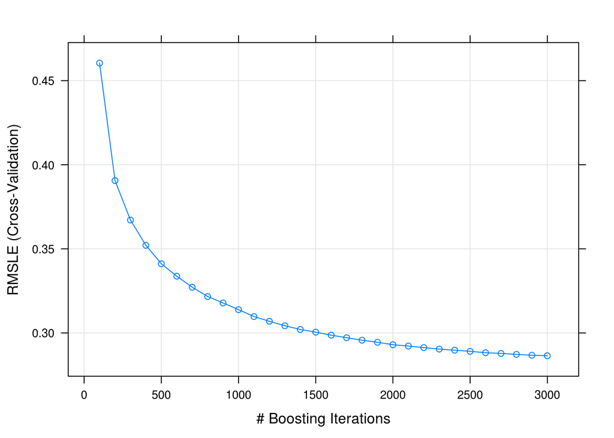

```r
## gbm fitting
set.seed(123)
fitControl <- trainControl(method = 'cv', number = 10, repeats=3, summaryFunction=my2metric)
Grid <- expand.grid( n.trees = seq(100,3000,100), interaction.depth = c(30), shrinkage = c(0.075))
formula <- count ~ season + workingday + weather + temp + atemp + humidity + windspeed + time + wday + month + year
fit.gbm <- train(formula, data=subTrain, method = 'gbm', trControl=fitControl, verbose=FALSE,tuneGrid=Grid,metric='RMSLE',maximize=FALSE,distribution='poisson')
compare<-tool.performance(fit.gbm,subTest,subTrain,'gbm.CV',compare)

#show(fit.gbm)
plot(fit.gbm)
```

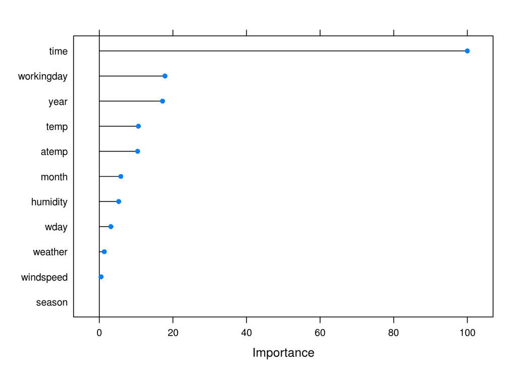

```r
gbmVarImp<-varImp(fit.gbm)
plot(gbmVarImp)
```

```r
write.submission(fit.gbm, 'submission_gbm_v3.csv',pp.test)
```

– The submission score is 0.44993 (ntree=3000, interaction=10, shrinkage=0.05, no repeats, 90% of training), no better than the ntree=250, shrinkage=0.075 result. Overfiting could be serious.

– With 80% of training sample, (ntree=3000, interaction=10, shrinkage=0.075, repeats=3), submission score improves to 0.439. (not good enough)

– Check the performance if some parameters are set to factor

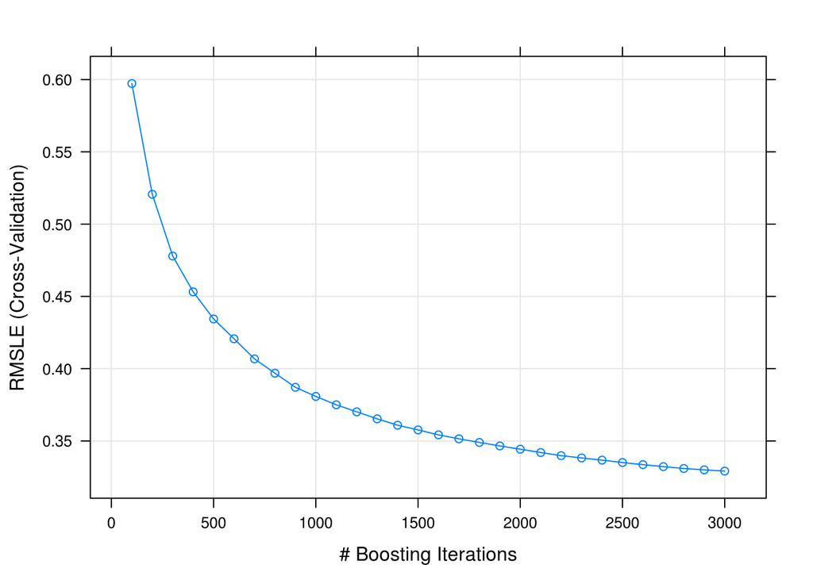

```r
set.seed(123)
fitControl <- trainControl(method = 'cv', number = 10, summaryFunction=my2metric)
Grid <- expand.grid( n.trees = seq(100,3000,100), interaction.depth = c(30), shrinkage = c(0.075))
subTrain2<-subTrain
subTest2 <- subTest
ind <- c(1,2,3,9,10,11)
for (i in ind) {subTrain2[,i] <- as.factor(subTrain2[,i])}
for (i in ind) {subTest2[,i] <- as.factor(subTest2[,i])}

formula <- count ~ season + workingday + weather + temp + atemp + humidity + windspeed + time + wday + month + year
fit.gbm.f <- train(formula, data=subTrain2, method = 'gbm', trControl=fitControl, verbose=FALSE,tuneGrid=Grid,metric='RMSLE',maximize=FALSE,distribution='poisson')
#show(fit.gbm.f)
plot(fit.gbm.f)
```

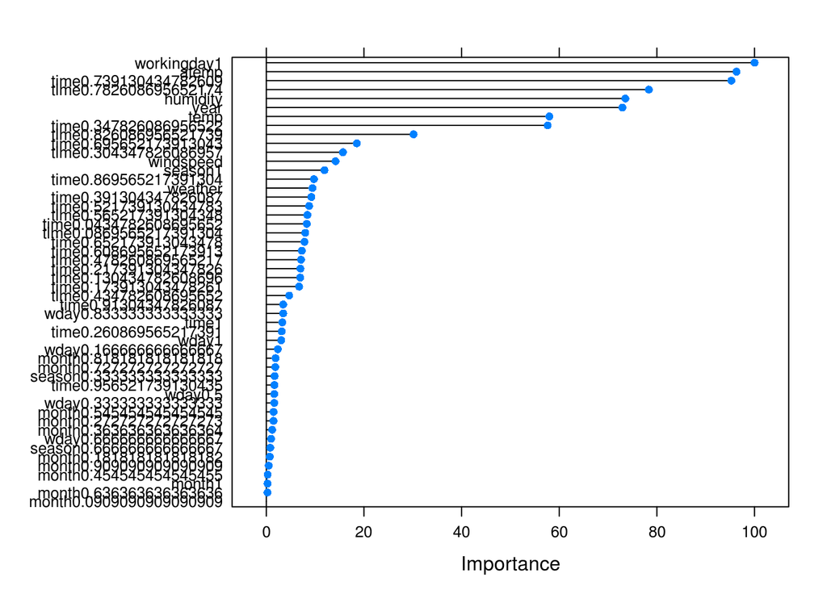

```r
compare<-tool.performance(fit.gbm.f,subTest2,subTrain2,'gbm.CV.f',compare)
gbmFVarImp<-varImp(fit.gbm.f)
plot(gbmFVarImp)
```

## regression only modeling

#### Model2: lasso / enet

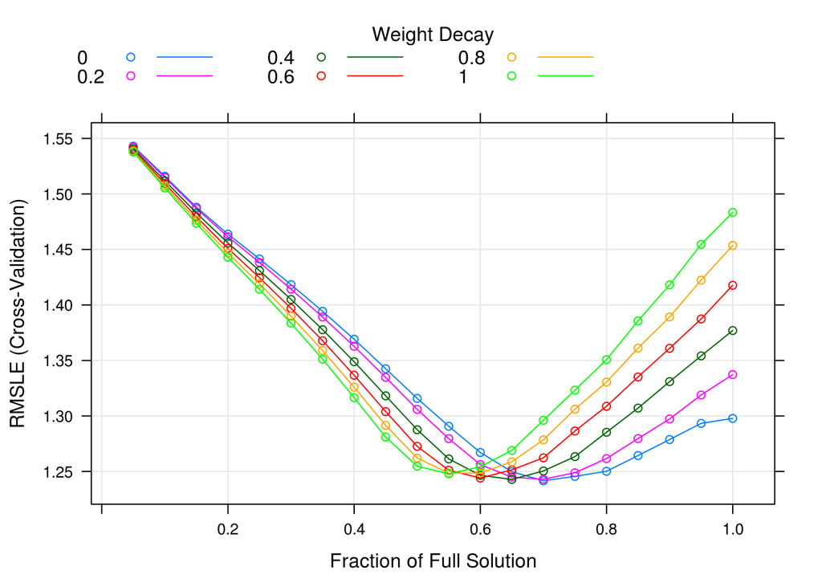

```r
#enet in caret/elasticnet
#when lambda = 0 -> lasso
set.seed(123)
fitControl <- trainControl(method = 'cv', number = 10, summaryFunction=my2metric)
Grid <- expand.grid( fraction = seq(0.05,1.0,0.05),lambda=seq(0,1.0,0.2))
formula <- count ~ season + workingday + weather + temp + atemp + humidity + windspeed + time + wday + month + year
fit.enet <- train(formula, data=subTrain, method = 'enet', trControl=fitControl,tuneGrid=Grid,metric='RMSLE', maximize=FALSE)
#show(fit.enet)
plot(fit.enet)
```

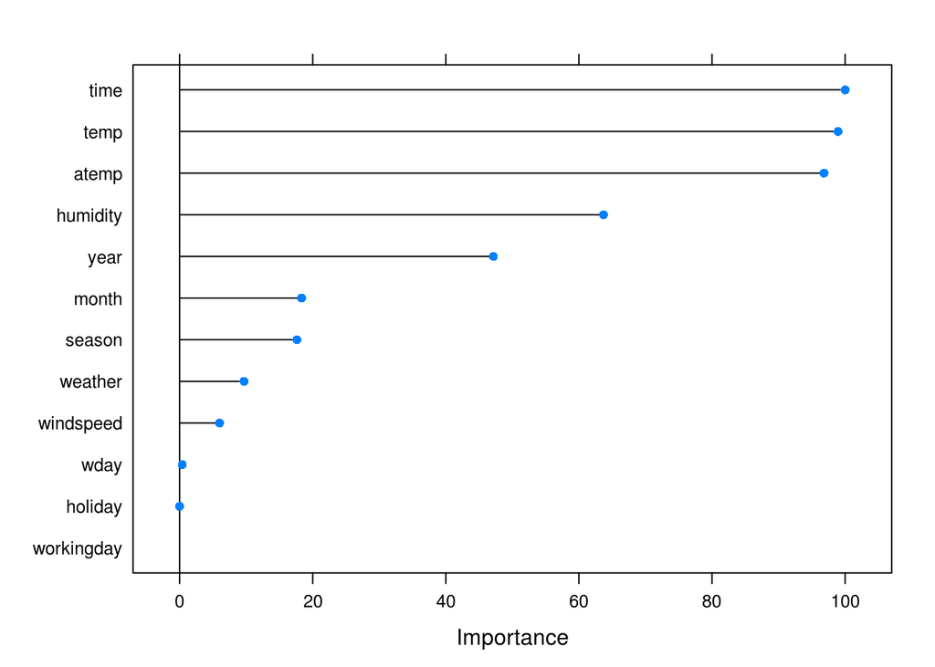

```r
compare<-tool.performance(fit.enet,subTest,subTrain,'enet.CV',compare)
enetVarImp<-varImp(fit.enet)
plot(enetVarImp)
```

#### Model3: pcr : principle componenet analsis

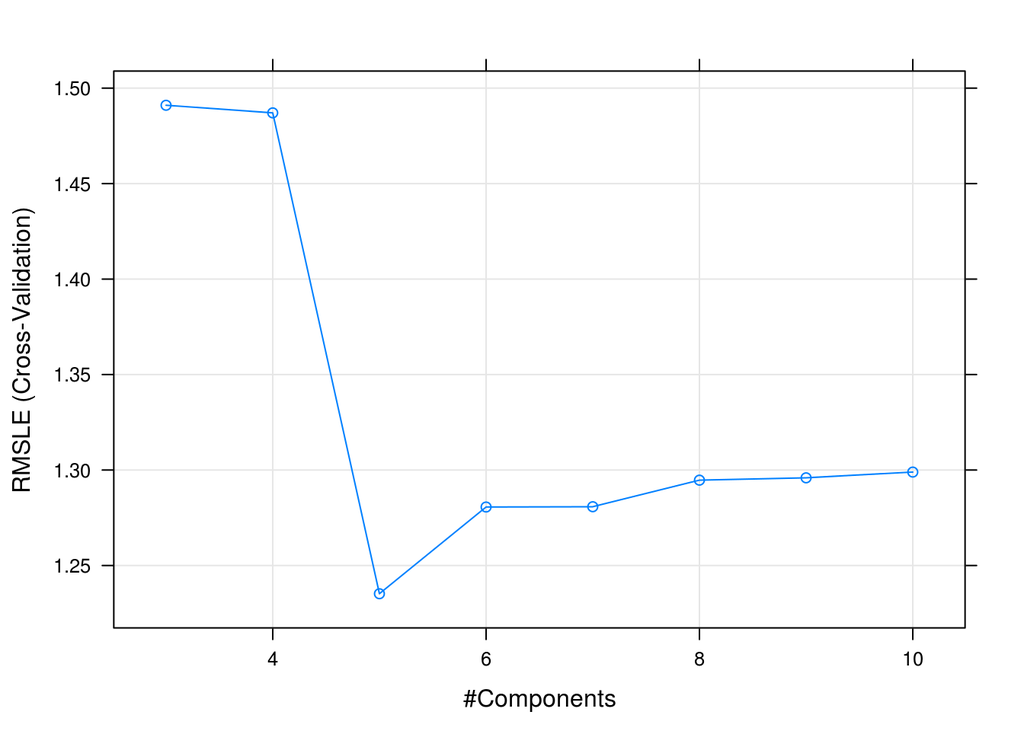

```r
#pcr in caret/pls
set.seed(123)
fitControl <- trainControl(method = 'cv', number = 10, summaryFunction=my2metric)
Grid <- expand.grid(ncomp = seq(3,10))
formula <- count ~ season + workingday + weather + temp + atemp + humidity + windspeed + time + wday + month + year
fit.pcr <- train(formula, data=subTrain, method = 'pcr', trControl=fitControl,metric='RMSLE', maximize=FALSE,tuneGrid=Grid)
#show(fit.pcr)
plot(fit.pcr)
```

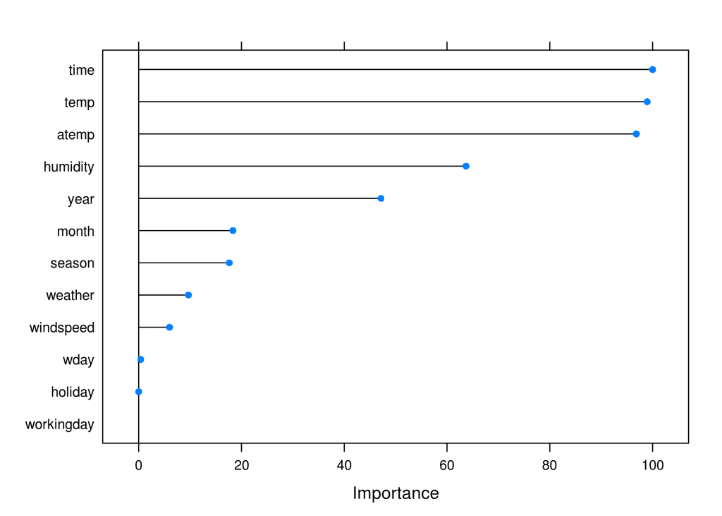

```r
compare<-tool.performance(fit.pcr,subTest,subTrain,'pcr.CV',compare)
pcrVarImp<-varImp(fit.pcr)
plot(pcrVarImp)
```

#### Model4: glmnet : another elastic-net regularization for linear regression

```
-- could use poission distribution
```

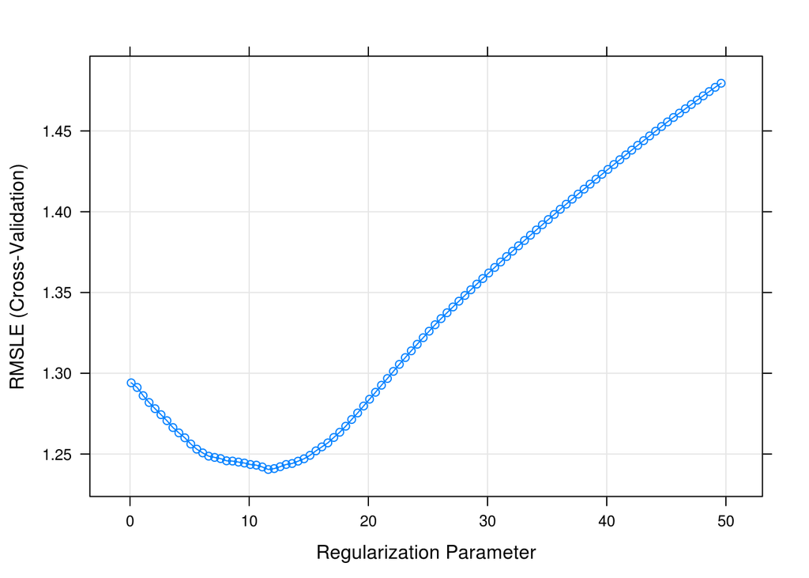

```r
#glmnet in caret/glmnet
set.seed(123)
fitControl <- trainControl(method = 'cv', number = 10, summaryFunction=my2metric)
Grid <- expand.grid(lambda = seq(0.1,50.0,0.5),alpha=c(1))
formula <- count ~ season + workingday + weather + temp + atemp + humidity + windspeed + time + wday + month + year
fit.glmnet <- train(formula, data=subTrain, method = 'glmnet', trControl=fitControl,metric='RMSLE', maximize=FALSE,tuneGrid=Grid)
#show(fit.glmnet)
plot(fit.glmnet)
```

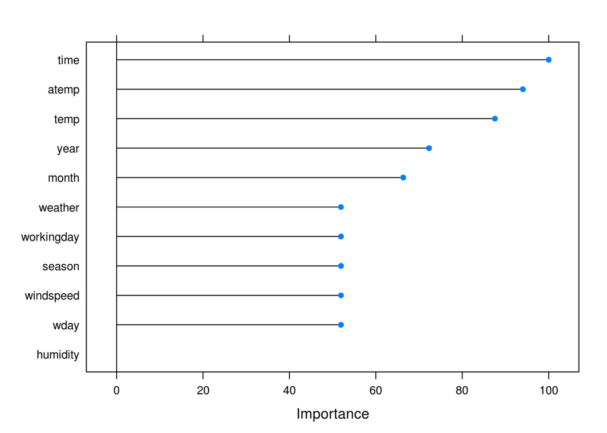

```r
compare<-tool.performance(fit.glmnet,subTest,subTrain,'glmnet.CV6',compare)
glmnetVarImp<-varImp(fit.glmnet)
plot(glmnetVarImp)
```

#### Model 4b: glmnet with second order interaction

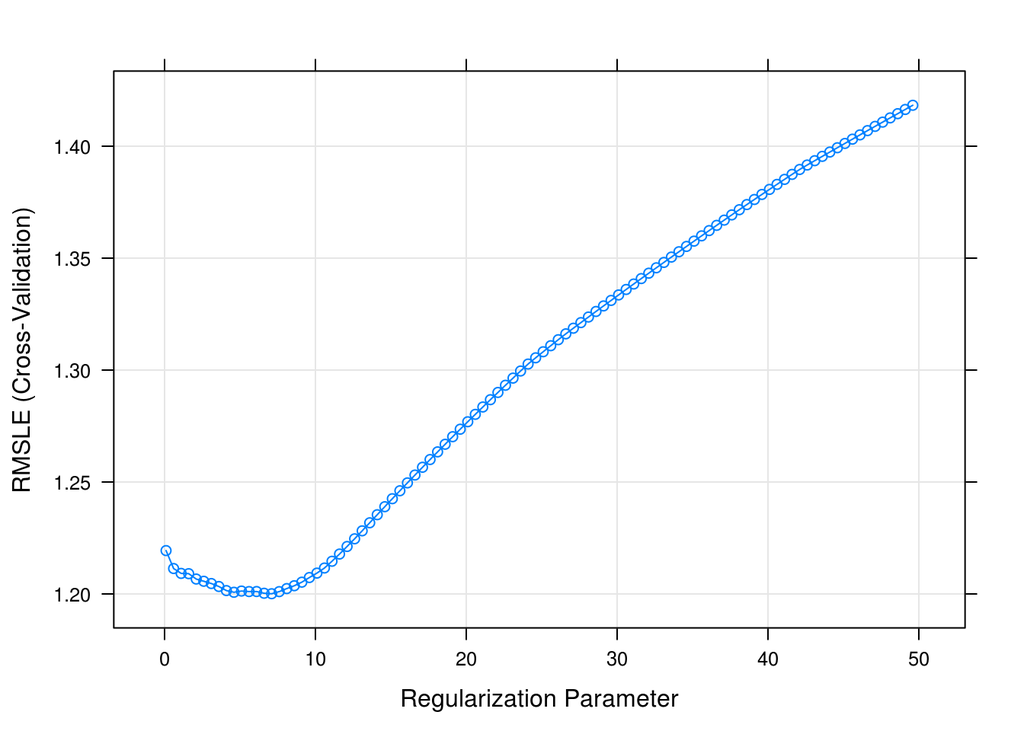

```r
set.seed(123)
fitControl <- trainControl(method = 'cv', number = 10, summaryFunction=my2metric)
Grid <- expand.grid(lambda = seq(0.1,50.0,0.5),alpha=c(1))
formula <- count ~ season + workingday + weather + temp + atemp + humidity + windspeed + time + wday + month + year + temp*time + time*atemp + time*year + temp*year + time*workingday + temp*workingday + atemp*workingday + time*time + temp*temp + atemp*atemp + workingday*workingday + atemp*atemp
fit.glmnet.2OrderInt <- train(formula, data=subTrain, method = 'glmnet', trControl=fitControl,metric='RMSLE', maximize=FALSE,tuneGrid=Grid)
plot(fit.glmnet.2OrderInt)
```

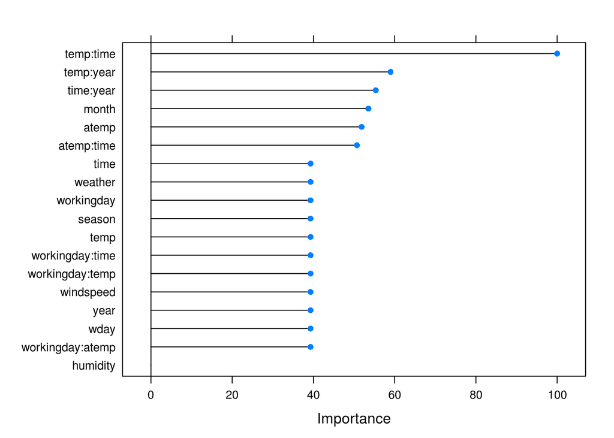

```r
compare<-tool.performance(fit.glmnet.2OrderInt,subTest,subTrain,'glmnet.2OInt.CV',compare)
glmnet2VarImp<-varImp(fit.glmnet.2OrderInt)
plot(glmnet2VarImp)
```

– Improve a little bit, but not much.

## Model: random forest family

#### Model5a: qrf : quantile random forest

– This is regression only, why? different from other random forest model

```r
#qrf in caret/quantregForest
set.seed(123)
fitControl <- trainControl(method = 'cv', number = 10, summaryFunction=my2metric)
Grid <- expand.grid(mtry = c(5,7,10))
formula <- count ~ season + workingday + weather + temp + atemp + humidity + windspeed + time + wday + month + year
fit.qrf <- train(formula, data=subTrain, method = 'qrf', trControl=fitControl,metric='RMSLE', maximize=FALSE,tuneGrid=Grid)
#show(fit.qrf)
plot(fit.qrf)
compare<-tool.performance(fit.qrf,subTest,subTrain,'qrf.CV',compare)
qrfVarImp<-varImp(fit.qrf)
plot(qrfVarImp)
write.submission(fit.qrf, 'submission_qrf_v1.csv',pp.test)
```

[output not shown]

– This is good. Well, a slow random forest based model is quite promising. Submit it, and see the result.

#### Model5b: rf : the simplest random forest

```r
#rf in caret/randomForest
set.seed(123)
fitControl <- trainControl(method = 'oop', summaryFunction=my2metric)
Grid <- expand.grid(mtry = c(5,7,10))
formula <- count ~ season + workingday + weather + temp + atemp + humidity + windspeed + time + wday + month + year
fit.rf <- train(formula, data=subTrain, method = 'rf', trControl=fitControl,metric='RMSLE', maximize=FALSE,tuneGrid=Grid)
#show(fit.rf)
plot(fit.rf)
compare<-tool.performance(fit.rf,subTest,subTrain,'rf.CV',compare)
rfVarImp<-varImp(fit.rf)
plot(rfVarImp)
write.submission(fit.rf, 'submission_rf_v2.csv',pp.test)
```

[output not shown]

## Model: SVM-family

#### Model6a: Radial kernal (caret/kernlab/rvmRadial)

– SVM/RVM is too slow, so that I need to reduce the DoF.

– Linear kernal won’t work, I should directly use Gaussian kernal.

– I will use rvm first, which use Bayseian inherence to optimize the model. Therefore, no need to use the regularization parameter C, but may be trapped at the local minimum.

```r
set.seed(123)
fitControl <- trainControl(method = 'cv', number = 6, summaryFunction=my2metric)
formula <- count ~ season + workingday + weather + temp + atemp + humidity + windspeed + time + wday + month + year
fit.rvmLinear <- train(formula, data=subTrain, method = 'rvmRadial', trControl=fitControl,metric='RMSLE', maximize=FALSE)
#show(fit.rvmLinear)
compare<-tool.performance(fit.rvmLinear,subTest,subTrain,'rvmRadial.CV',compare)
rvmLinearVarImp<-varImp(fit.rvmLinear)
plot(rvmLinearVarImp)
```

[output not shown]

#### Model6b: Gaussian kernal (caret/kernlab/rvmRadial)